# Estimating the early death toll of COVID-19 in the United States

9/4/2020

Dan Weinberger,<sup>1</sup> Jenny Chen,<sup>7</sup> Ted Cohen,<sup>1</sup> Forrest W. Crawford,<sup>2</sup> Farzad Mostashari,<sup>3</sup> Don Olson,<sup>4</sup> Virginia E Pitzer,<sup>1</sup> Nicholas G Reich,<sup>5</sup> Marcus Russi,<sup>1</sup> Lone Simonsen,<sup>6</sup> Annie Watkins,<sup>1</sup> Cecile Viboud<sup>7</sup>

<sup>1</sup>Department of Epidemiology of Microbial Diseases and the Public Health Modeling Unit, Yale School of Public Health, New Haven, CT <sup>2</sup>Department of Biostatistics and the Public Health Modeling Unit, Yale School of Public Health, New Haven, CT; Yale Departments of Ecology and Evolutionary Biology, Statistics & Data Science, Yale School of Management <sup>3</sup>Aledade, Inc <sup>4</sup>Department of Health and Mental Hygiene, New York City, NY <sup>5</sup>Department of Biostatistics and Epidemiology, School of Public Health and Health Sciences, University of Massachusetts, Amherst, MA <sup>6</sup>Department of Science and Environment, Roskilde University, Denmark <sup>7</sup>Division of International Epidemiology and Population Studies, Fogarty International Center, National Institutes of Health, Bethesda, MD

## Overview

*Background* Efforts to track the severity and public health impact of the novel coronavirus, COVID-19, in the US have been hampered by testing issues, reporting lags, and inconsistency between states. Evaluating unexplained increases in deaths attributed to broad outcomes, such as pneumonia and influenza or due to all causes, can provide a more complete and consistent picture of the burden caused by COVID-19.

*Methods* We evaluated increases in the occurrence of deaths due to any cause above a seasonal baseline (adjusted for influenza activity) or deaths due to coronaivirus/P&I (P&I&C) for March-early-May across the United States. These estimates are compared with reported deaths due to COVID-19 and with testing data. Detailed methods can be found [here](https://github.com/weinbergerlab/excess_pi_covid/blob/master/post%20methods.pdf)

*Conclusions* Excess deaths provide an estimate of full COVID-19 burden and indicate that official tallies likely undercount deaths due to the virus.

## National all-cause excess

Excess deaths for the United States from March 1, 2020 through Aug 22, 2020. The observed number of deaths is indicated by the black solid line, and the expected number of deaths, adjusting for seasonality, influenza epidemics, and reporting delays, is indicated by the black dashed line. The area between these two lines represents the total number of excess deaths. The blue area represents deaths recorded as due to COVID-19, the red shaded area presents additional pneumonia and influenza excess deaths not coded as due to COVID-19, and the green shaded area represents deaths that were not attributed to COVID-19 or pneumonia or influenza.

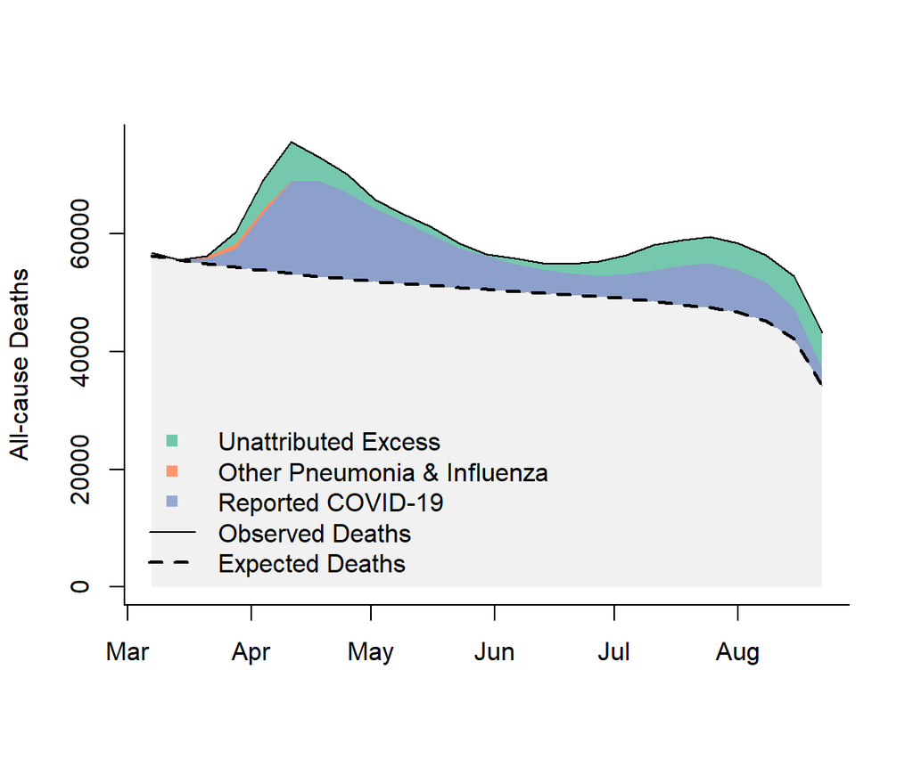

Alternative plot

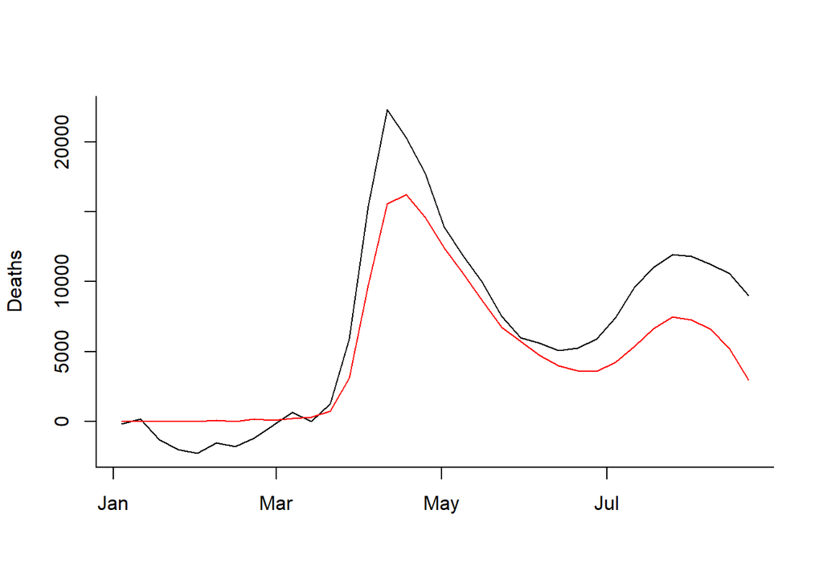

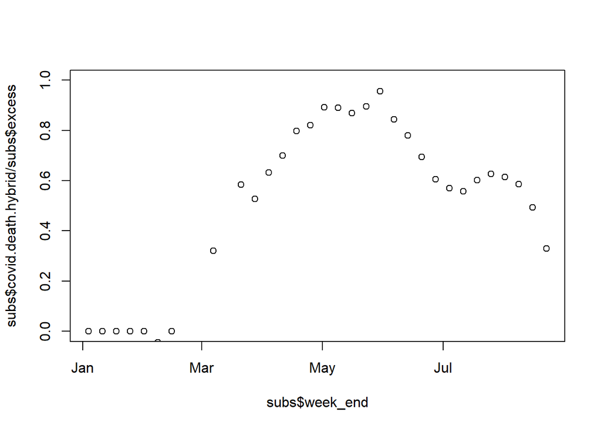

## Excess deaths in New York City and the rest of New York

Excess deaths for New York state (excluding New York City) and for New York City from March 1, 2020 through Aug 22, 2020. The observed number of deaths is indicated by the black solid line, and the expected number of deaths, adjusting for seasonality, influenza epidemics, and reporting delays, is indicated by the black dashed line. The area between these two lines represents the total number of excess deaths. The blue area represents deaths recorded as due to COVID-19, the red shaded area presents additional pneumonia and influenza excess deaths not coded as due to COVID-19, and the green shaded area represents deaths that were not attributed to COVID-19 or pneumonia or influenza.

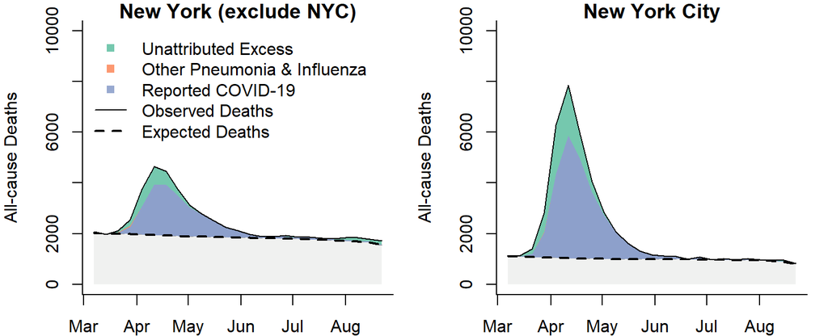

## Excess deaths in four high-incidence states

Excess deaths for four states that had large numbers of reported COVID-19 deaths from March 1, 2020 through Aug 22, 2020. The observed number of deaths is indicated by the black solid line, and the expected number of deaths, adjusting for seasonality, influenza epidemics, and reporting delays, is indicated by the black dashed line. Area between these two lines represents the total number of excess deaths. The blue area represents deaths recorded as due to COVID-19, the red shaded area presents additional pneumonia and influenza excess deaths not coded as due to COVID-19, and the green shaded area represents deaths that were not attributed to COVID-19 or pneumonia or influenza.

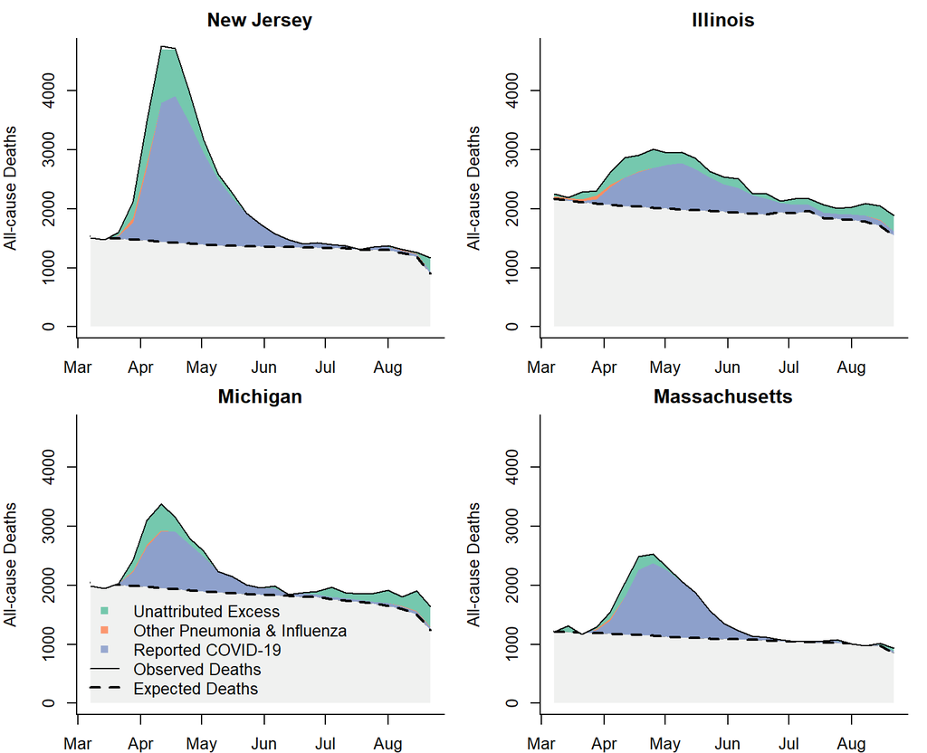

## Excess deaths in select additional states

Excess deaths for additional states from March 1, 2020 through Aug 22, 2020. The observed number of deaths is indicated by the black solid line, and the expected number of deaths, adjusting for seasonality, influenza epidemics, and reporting delays, is indicated by the black dashed line. Area between these two lines represents the total number of excess deaths. The blue area represents deaths recorded as due to COVID-19, the red shaded area presents additional pneumonia and influenza excess deaths not coded as due to COVID-19, and the green shaded area represents deaths that were not attributed to COVID-19 or pneumonia or influenza.

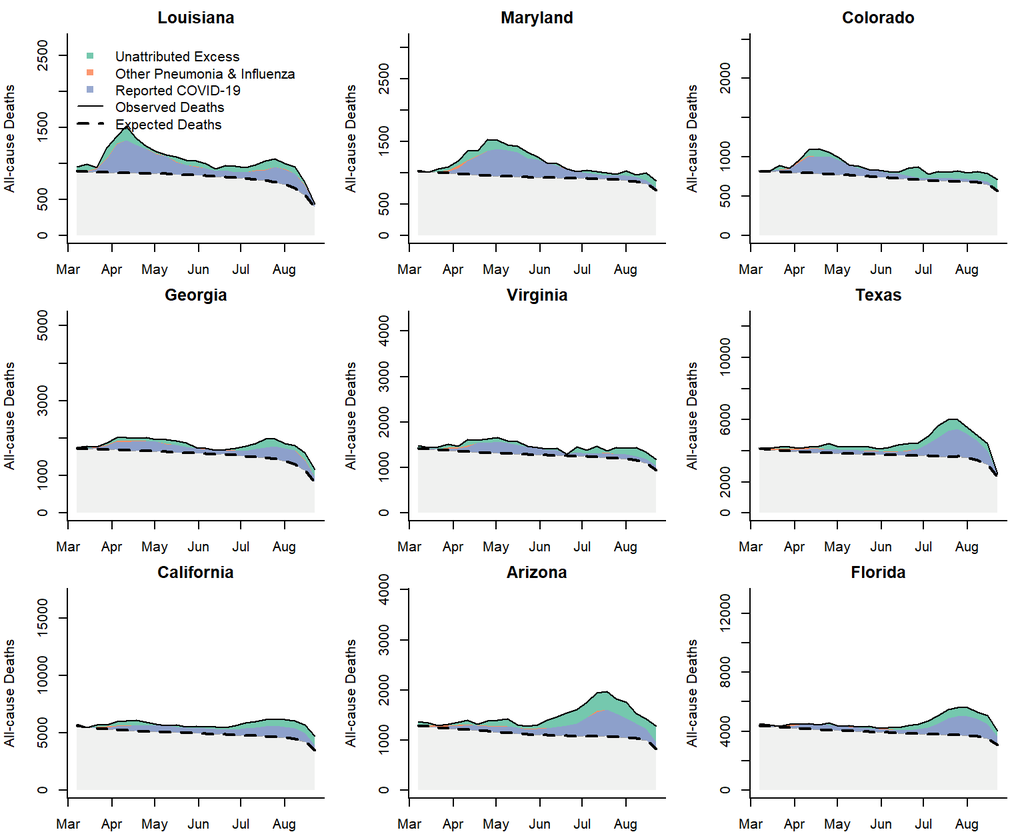

## Summary Table: Excess deaths and reported deaths due to COVID-19

| Observed and Excess deaths due to COVID-19, pneumonia/influenza/Covid-19, and all-causes COVID-19, from March 1, 2020 through Aug 22, 2020 State | Observed and Excess deaths due to COVID-19, pneumonia/influenza/Covid-19, and all-causes COVID-19, from March 1, 2020 through Aug 22, 2020 Observed Deaths | Observed and Excess deaths due to COVID-19, pneumonia/influenza/Covid-19, and all-causes COVID-19, from March 1, 2020 through Aug 22, 2020 Expected deaths | Observed and Excess deaths due to COVID-19, pneumonia/influenza/Covid-19, and all-causes COVID-19, from March 1, 2020 through Aug 22, 2020 Excess all-cause deaths | Observed and Excess deaths due to COVID-19, pneumonia/influenza/Covid-19, and all-causes COVID-19, from March 1, 2020 through Aug 22, 2020 COVID-19 deaths (U07.1) | Observed and Excess deaths due to COVID-19, pneumonia/influenza/Covid-19, and all-causes COVID-19, from March 1, 2020 through Aug 22, 2020 Excess Pneumonia/Influenza/Covid-19 deaths | Observed and Excess deaths due to COVID-19, pneumonia/influenza/Covid-19, and all-causes COVID-19, from March 1, 2020 through Aug 22, 2020 Excess all-cause deaths/100,000 |
| --- | --- | --- | --- | --- | --- | --- |
| US | 1486935 | 1249600 | 237600 (226000,246400) | 166307 | 161690 (158890,164210) | 72.4 (68.9,75.1) |
| NYC | 51509 | 24800 | 26700 (26200,27100) | 20634 | 19250 (18990,19470) | 317.6 (311.4,322.8) |
| NJ | 51770 | 34000 | 17800 (17200,18300) | 14142 | 14210 (14030,14370) | 200.5 (193.6,206.3) |
| DC | 3696 | 2800 | 900 (800,1100) | 694 | 690 (630,730) | 132.6 (108.4,153.3) |
| LA | 26072 | 20000 | 6100 (5700,6500) | 4209 | 4250 (4150,4350) | 130.9 (121.8,140.3) |
| NY | 60302 | 46100 | 14200 (13500,14800) | 11526 | 10720 (10460,10920) | 128.6 (122.2,133.9) |
| MS | 18186 | 14600 | 3600 (3200,4000) | 2230 | 2160 (2040,2270) | 121.6 (109.2,133.2) |
| AZ | 36998 | 28100 | 8800 (8400,9300) | 4595 | 4680 (4550,4820) | 121.4 (115,128.4) |
| MA | 35475 | 27300 | 8200 (7700,8700) | 7996 | 7630 (7480,7780) | 118.9 (111.8,125.9) |
| RI | 5621 | 4500 | 1100 (900,1300) | 998 | 930 (860,980) | 102.1 (82,119.7) |
| DE | 5118 | 4100 | 1000 (800,1200) | 531 | 520 (470,570) | 101.5 (81.8,119.6) |
| MD | 28918 | 23300 | 5600 (5200,6100) | 4030 | 4010 (3870,4130) | 93.4 (86.4,101) |
| IL | 59983 | 48700 | 11300 (10600,11900) | 7302 | 7100 (6940,7280) | 88.8 (83.6,93.5) |
| MI | 54179 | 45400 | 8800 (8100,9400) | 6025 | 5830 (5660,6020) | 88.3 (80.9,94.2) |
| AL | 28305 | 24000 | 4300 (3800,4700) | 2614 | 2760 (2650,2860) | 86.8 (77.5,96.8) |
| SC | 27230 | 23000 | 4200 (3700,4700) | 2210 | 2130 (2020,2240) | 81.4 (72.2,90.7) |
| FL | 115752 | 98600 | 17200 (16100,18100) | 11129 | 11380 (11120,11630) | 79.9 (75,84.1) |
| TX | 112735 | 92700 | 20000 (19100,20900) | 12392 | 12510 (12290,12760) | 69.1 (65.9,72.2) |
| GA | 45526 | 38500 | 7000 (6400,7600) | 4602 | 4700 (4560,4840) | 66 (60.3,71.8) |
| PA | 70055 | 62400 | 7600 (6900,8300) | 7946 | 7480 (7280,7660) | 59.5 (53.6,64.9) |
| IN | 34397 | 30500 | 3900 (3300,4300) | 3181 | 3100 (2970,3250) | 57.3 (49.5,64.3) |
| CO | 21805 | 18500 | 3300 (2800,3700) | 1873 | 1800 (1690,1910) | 56.7 (49.2,64.2) |
| TN | 38398 | 34600 | 3800 (3200,4400) | 1577 | 1660 (1490,1800) | 56.1 (46.8,64.6) |
| VA | 36501 | 31900 | 4600 (4100,5100) | 2688 | 2510 (2390,2630) | 53.8 (48.2,60.1) |
| CA | 143621 | 123100 | 20500 (19300,21500) | 12548 | 12160 (11860,12440) | 51.9 (48.9,54.4) |
| OH | 61412 | 55600 | 5800 (5100,6500) | 3705 | 3700 (3540,3840) | 49.9 (43.7,55.2) |
| AR | 16263 | 14800 | 1500 (1100,1800) | 807 | 830 (730,910) | 49.4 (37,60.7) |
| VT | 2891 | 2600 | 300 (100,400) | 58 | 10 (-40,50) | 47.3 (22.6,69.2) |
| NV | 13844 | 12400 | 1400 (1000,1700) | 1151 | 1140 (1060,1230) | 45.5 (33.1,55.7) |
| NM | 9651 | 8700 | 900 (700,1200) | 717 | 670 (600,740) | 45 (31.9,58.8) |
| NH | 6400 | 5800 | 600 (400,800) | 407 | 350 (290,410) | 42.6 (26.4,59.4) |
| KY | 23366 | 21700 | 1600 (1200,2100) | 947 | 980 (860,1100) | 36.5 (26.6,46.1) |
| MO | 31567 | 29300 | 2200 (1700,2700) | 1509 | 1560 (1450,1670) | 36.4 (27.7,43.9) |
| OK | 19188 | 17800 | 1400 (1000,1800) | 820 | 800 (680,910) | 36.2 (26,45.7) |
| WA | 29226 | 26500 | 2700 (2200,3100) | 1701 | 1650 (1540,1770) | 35.1 (28.7,41.3) |
| MN | 22893 | 21100 | 1800 (1400,2200) | 1785 | 1680 (1580,1790) | 32.7 (24.5,39.9) |
| WI | 27073 | 25200 | 1800 (1300,2300) | 1113 | 990 (890,1100) | 31.7 (23.1,39.2) |
| ID | 7307 | 6800 | 500 (300,800) | 340 | 320 (270,370) | 30.3 (17.1,44.8) |
| NE | 8428 | 7800 | 600 (300,800) | 382 | 320 (240,380) | 29.7 (17,43.3) |
| UT | 10103 | 9200 | 900 (600,1100) | 402 | 380 (320,450) | 27.4 (17.8,35.6) |
| KS | 13105 | 12400 | 700 (400,1000) | 529 | 440 (350,510) | 25.3 (14.3,35.8) |
| IA | 15101 | 14300 | 800 (500,1100) | 1084 | 920 (820,1000) | 25 (14.6,36.2) |
| OR | 17994 | 17000 | 1000 (600,1400) | 424 | 360 (290,450) | 24.4 (15.3,33.2) |
| MT | 4982 | 4700 | 200 (100,400) | 92 | 60 (10,100) | 23.2 (5,40.7) |
| WY | 2346 | 2200 | 100 (-100,200) | 33 | 30 (-10,60) | 16.8 (-11.6,40.6) |
| ME | 7134 | 7000 | 200 (-100,400) | 129 | -20 (-110,50) | 12.8 (-6.7,29.3) |
| AK | 2039 | 2000 | 0 (-100,100) | 30 | 0 (-30,30) | 0.5 (-18.6,17.1) |
| SD | 3838 | 3800 | 0 (-200,200) | 168 | 160 (110,200) | -0.8 (-19.9,18.4) |
| HI | 5481 | 5500 | 0 (-300,200) | 28 | -10 (-60,40) | -1.1 (-18.5,13.5) |
| ND | 3471 | 3500 | 0 (-200,200) | 134 | 180 (130,220) | -4.9 (-26.2,20.2) |
| WV | 9680 | 10000 | -300 (-600,0) | 140 | 140 (60,210) | -17.1 (-34.4,-1.8) |

## Observed weekly death rate due to any cause vs seasonal baseline (+/-95% Prediction Interval)

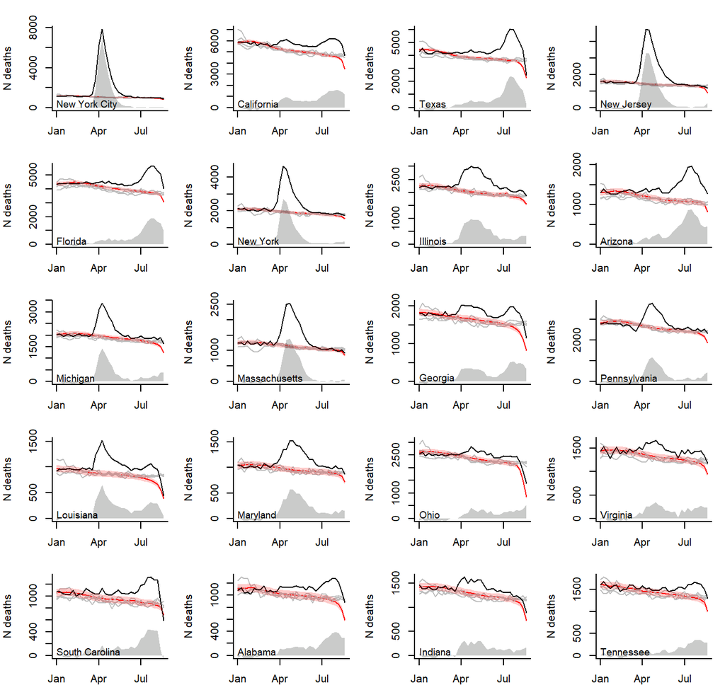

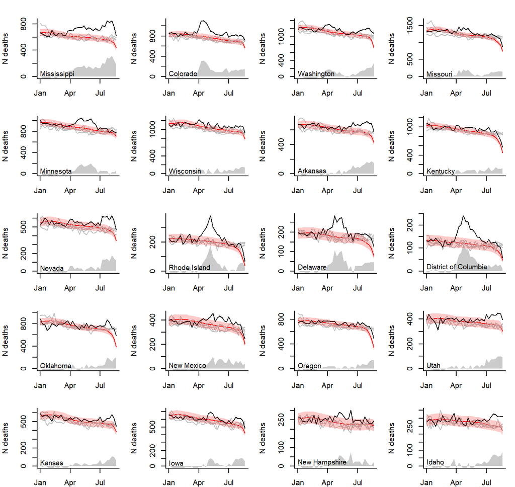

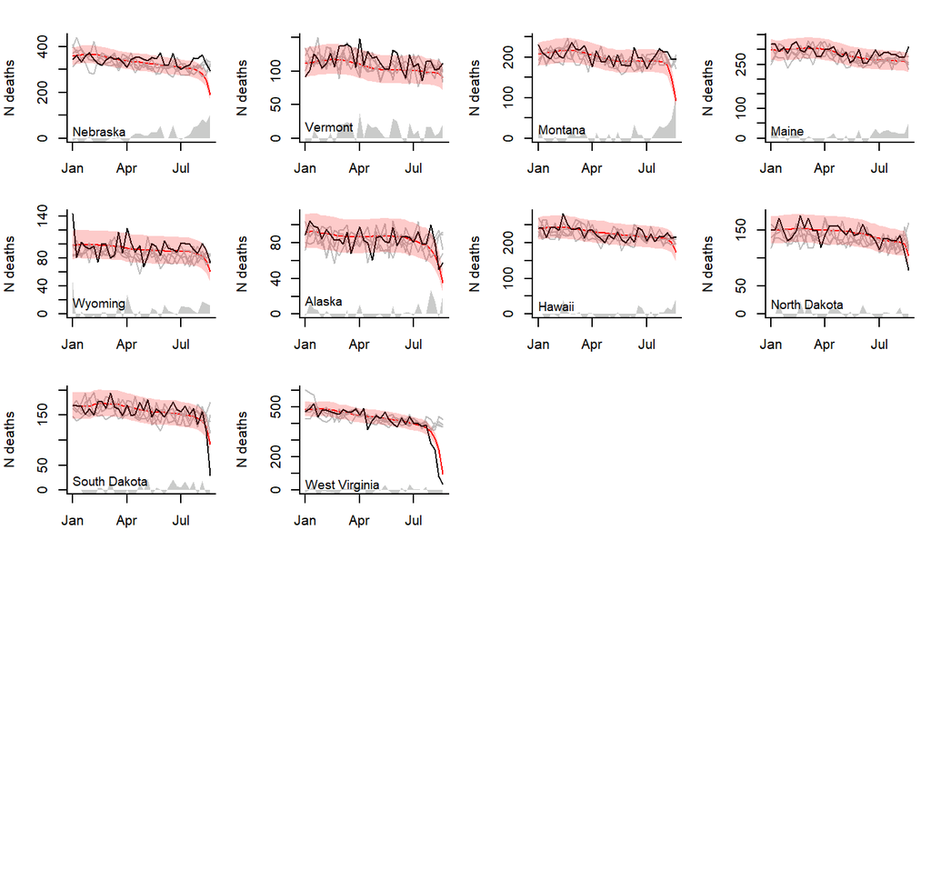

## Time series of observed and expected prior to March 2020

This is to demonstrate the fit of the model in the pre-pandemic period. Note: the axes do not extend to 0 because these plots are meant to highlight the fit of the model

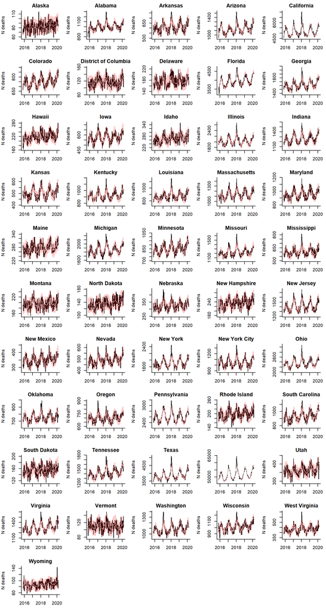

## Observed weekly death rate due to pneumonia/influenza/covid-19 vs seasonal baseline for pneumonia&influenza (+/-95% Prediction Interval)

The black line shows the observed proportion of deaths that were due to Pneumonia & Influenza & Covid-19 (P&I&C) per week. The red line and shaded area represent the 95% Prediction Interval. The latest P&I&C data is for the week ending 2020-08-22.

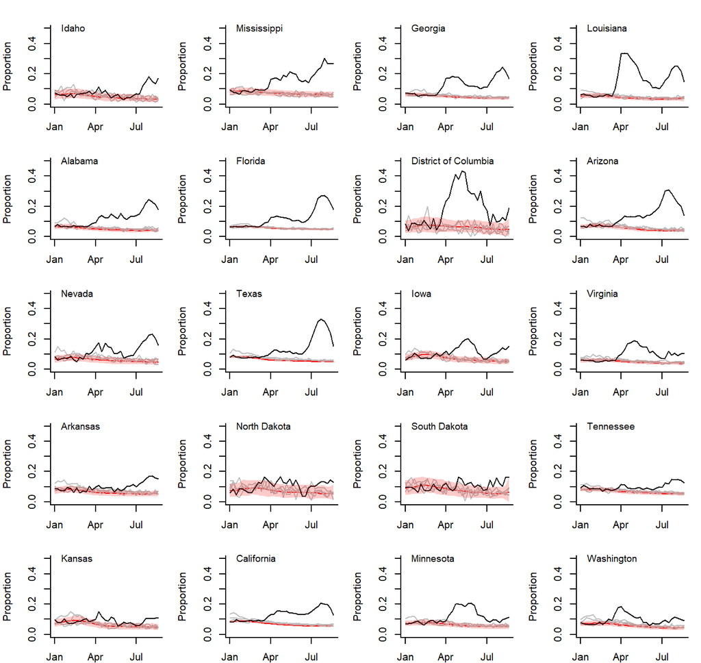

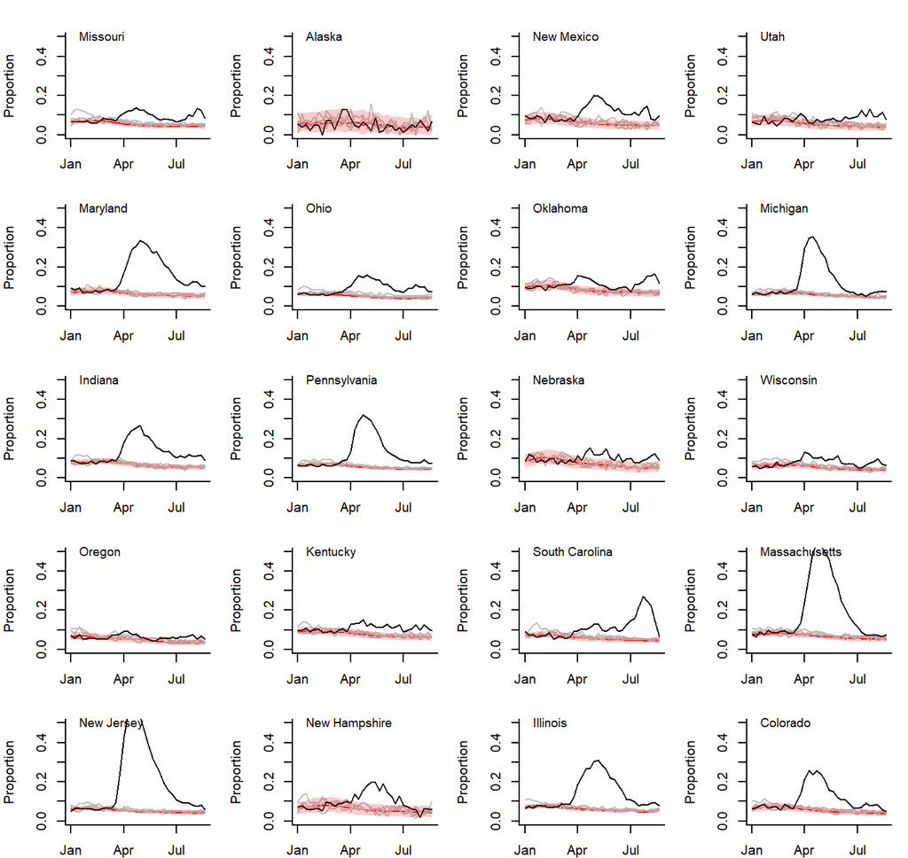

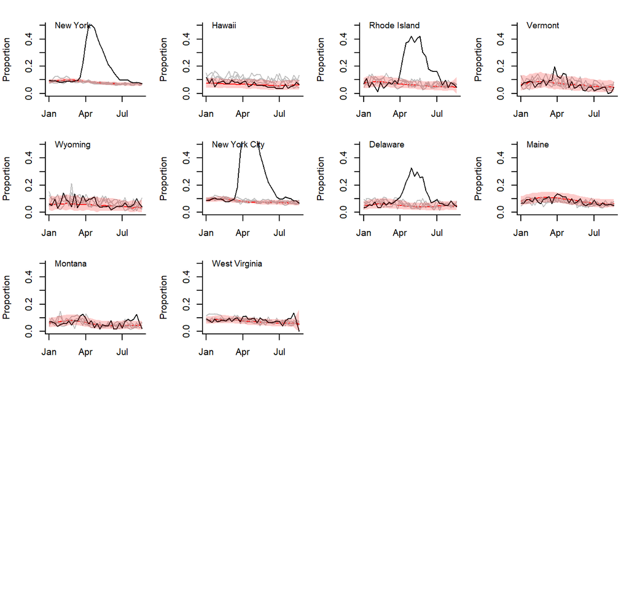

## Reported number of COVID-19 deaths,compared with the excess deaths due to all causes in each week, by state.

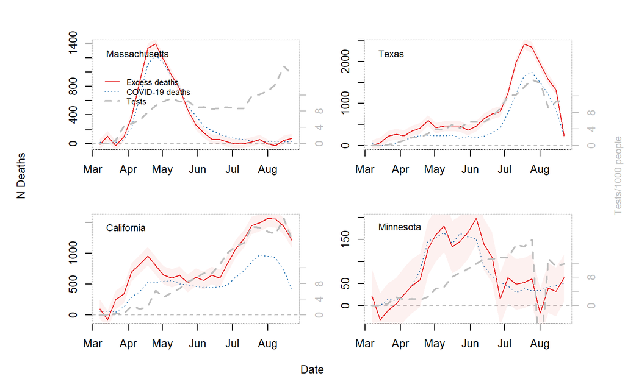

Same thing, for additional states

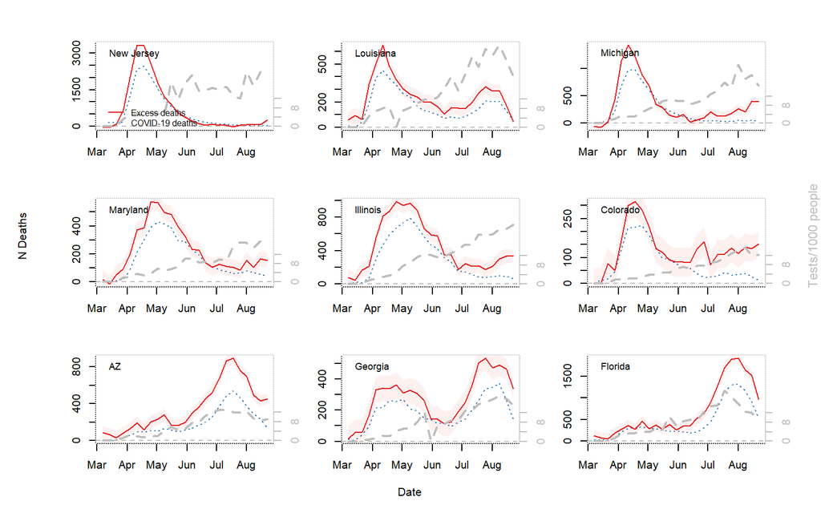

## NCHS vs COVIDtracking.com data

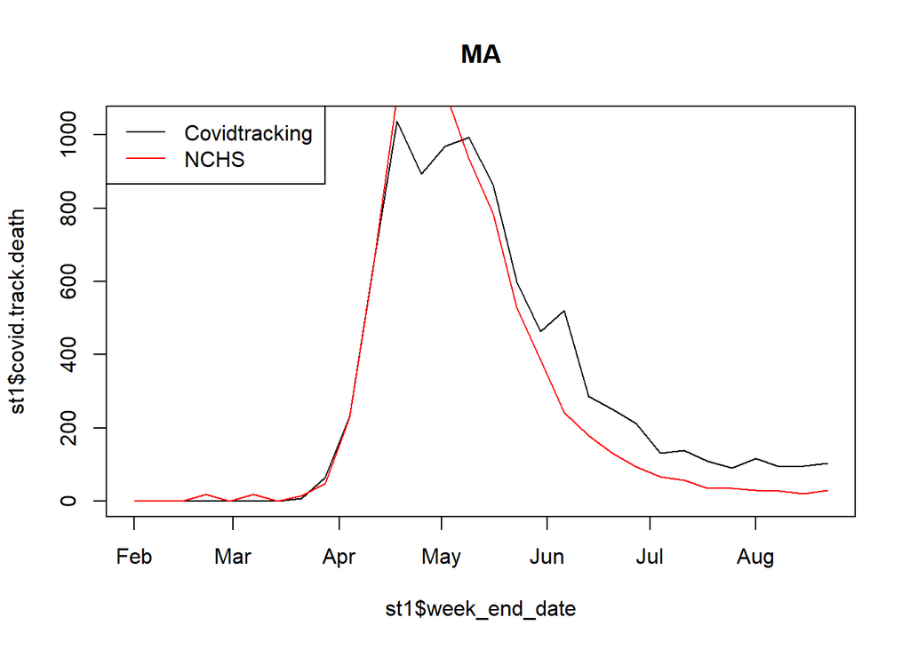

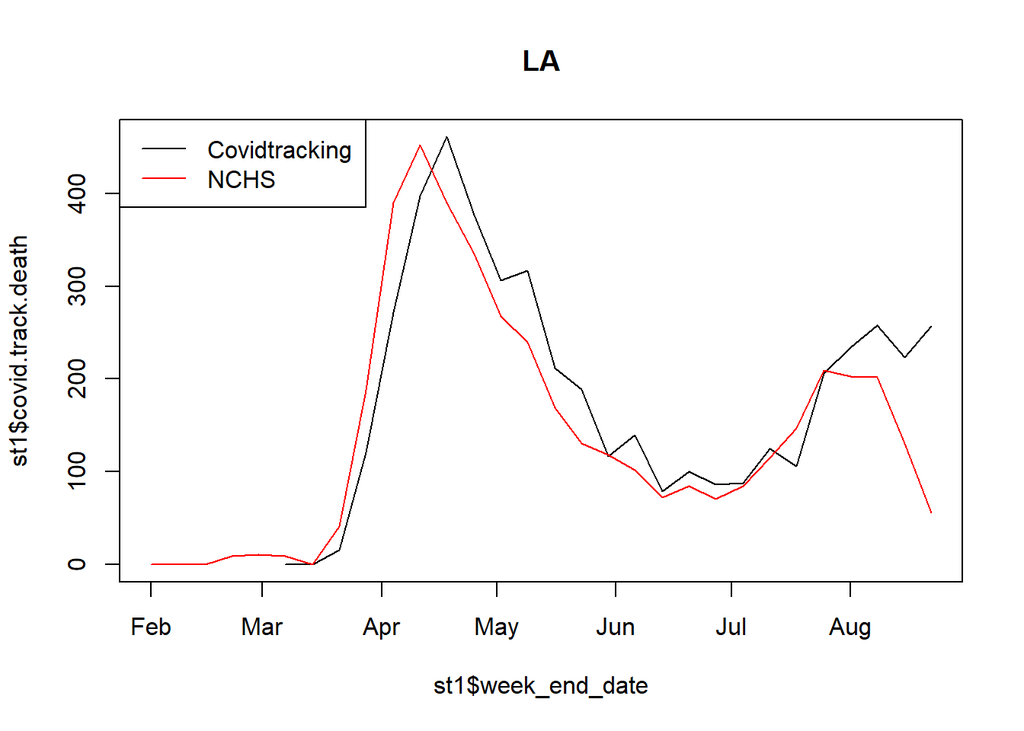

## Compare Excess all-cause mortality vs Excess ILI

Here we compare the observed vs expected number of deaths due to all causes in each week compared to the observed vs expected number of outpatient visits for influenza-like illness (ILI) in each week. we would expect ILI (blue line) to increase earlier than deaths (red line)

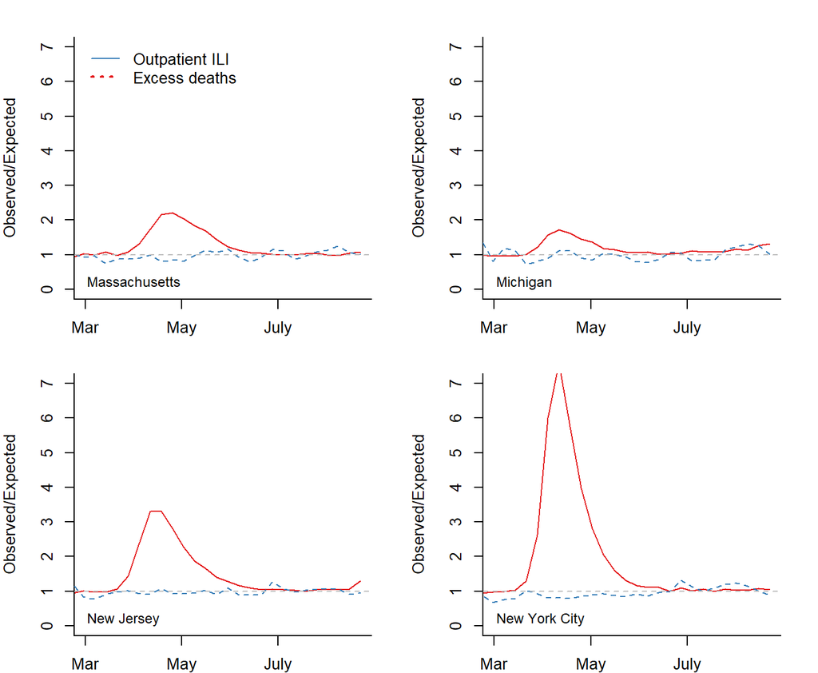

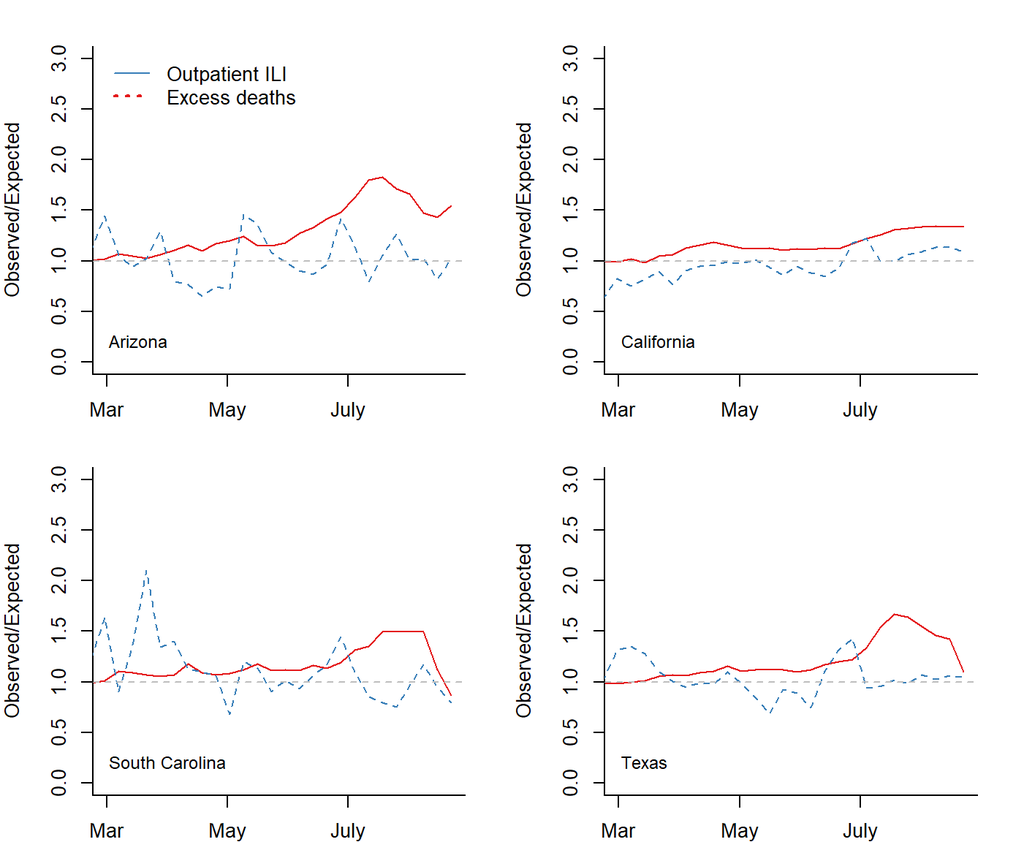

## Evaluation of reporting delays with provisional data

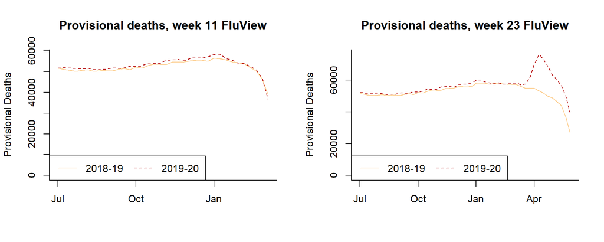

## Sensitivity analysis: do not Adjust for flu

| Comparison of excess deaths due to any cause, as estimated from a regression that adjusts for influenza with a regression that does not, with or without adjustments for reporting delays | Comparison of excess deaths due to any cause, as estimated from a regression that adjusts for influenza with a regression that does not, with or without adjustments for reporting delays State | Comparison of excess deaths due to any cause, as estimated from a regression that adjusts for influenza with a regression that does not, with or without adjustments for reporting delays Excess deaths, adjusted for influenza | Comparison of excess deaths due to any cause, as estimated from a regression that adjusts for influenza with a regression that does not, with or without adjustments for reporting delays Excess deaths, unadjusted for influenza |
| --- | --- | --- | --- |
| 1 | AK | 0 (-100,100) | 20 (-110,140) |
| 2 | AL | 4300 (3800,4700) | 3890 (3430,4320) |
| 3 | AR | 1500 (1100,1800) | 1460 (1100,1790) |
| 4 | AZ | 8800 (8400,9300) | 7790 (7250,8260) |
| 5 | CA | 20500 (19300,21500) | 19170 (18180,20130) |
| 6 | CO | 3300 (2800,3700) | 2980 (2550,3350) |
| 7 | DC | 900 (800,1100) | 870 (720,1010) |
| 8 | DE | 1000 (800,1200) | 970 (780,1150) |
| 9 | FL | 17200 (16100,18100) | 15800 (14860,16700) |
| 10 | GA | 7000 (6400,7600) | 6480 (5910,7000) |
| 11 | HI | 0 (-300,200) | -50 (-270,150) |
| 12 | IA | 800 (500,1100) | 830 (440,1150) |
| 13 | ID | 500 (300,800) | 500 (260,730) |
| 14 | IL | 11300 (10600,11900) | 11120 (10420,11710) |
| 15 | IN | 3900 (3300,4300) | 3830 (3300,4320) |
| 16 | KS | 700 (400,1000) | 680 (330,980) |
| 17 | KY | 1600 (1200,2100) | 1400 (960,1810) |
| 18 | LA | 6100 (5700,6500) | 5390 (4950,5780) |
| 19 | MA | 8200 (7700,8700) | 7600 (7090,8050) |
| 20 | MD | 5600 (5200,6100) | 5520 (5060,5940) |
| 21 | ME | 200 (-100,400) | 70 (-170,310) |
| 22 | MI | 8800 (8100,9400) | 8400 (7750,9000) |
| 23 | MN | 1800 (1400,2200) | 1680 (1250,2080) |
| 24 | MO | 2200 (1700,2700) | 2060 (1550,2530) |
| 25 | MS | 3600 (3200,4000) | 3590 (3230,3910) |
| 26 | MT | 200 (100,400) | 220 (0,410) |
| 27 | ND | 0 (-200,200) | -70 (-250,100) |
| 28 | NE | 600 (300,800) | 600 (330,840) |
| 29 | NH | 600 (400,800) | 560 (330,770) |
| 30 | NJ | 17800 (17200,18300) | 17290 (16740,17810) |
| 31 | NM | 900 (700,1200) | 830 (550,1080) |
| 32 | NV | 1400 (1000,1700) | 1400 (1060,1710) |
| 33 | NY | 14200 (13500,14800) | 13540 (12920,14140) |
| 34 | NYC | 26700 (26200,27100) | 26400 (25910,26820) |
| 35 | OH | 5800 (5100,6500) | 5640 (4920,6300) |
| 36 | OK | 1400 (1000,1800) | 1430 (1010,1780) |
| 37 | OR | 1000 (600,1400) | 990 (600,1350) |
| 38 | PA | 7600 (6900,8300) | 7670 (6920,8360) |
| 39 | RI | 1100 (900,1300) | 1070 (860,1250) |
| 40 | SC | 4200 (3700,4700) | 3980 (3510,4390) |
| 41 | SD | 0 (-200,200) | -30 (-230,140) |
| 42 | TN | 3800 (3200,4400) | 3030 (2500,3550) |
| 43 | TX | 20000 (19100,20900) | 17380 (16480,18220) |
| 44 | UT | 900 (600,1100) | 820 (540,1080) |
| 45 | VA | 4600 (4100,5100) | 4210 (3650,4690) |
| 46 | VT | 300 (100,400) | 290 (140,430) |
| 47 | WA | 2700 (2200,3100) | 2320 (1810,2770) |
| 48 | WI | 1800 (1300,2300) | 1490 (1020,1930) |
| 49 | WV | -300 (-600,0) | -350 (-630,-70) |
| 50 | WY | 100 (-100,200) | 120 (-30,250) |

## Empirical baseline

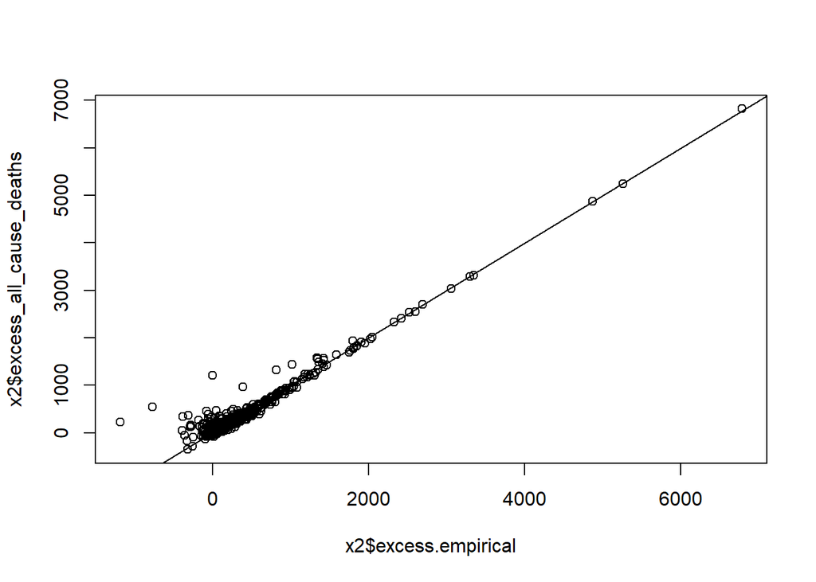

```
#> [1] 232266.5
#> [1] 237408
```

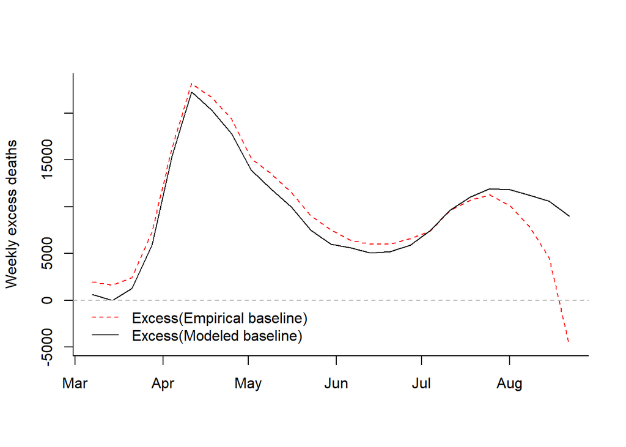